# Resolución Actividad 3 máster Bioinformática UNIR (2025)

Virginia García-Loygorri Arias, Rita Pellissa Valera, Samuel Pintos González, Tamara Noya Mosquera, Vanesa de las Heras Hermosilla, Yannis Avlonitis Egea

2025-12-30

# Introducción y objetivos

En esta actividad práctica se aplican los conocimientos adquiridos durante la asignatura de Estadística y R para realizar un flujo de trabajo bioinformático completo. El objetivo es analizar un conjunto de datos clínicos y de actividad génica para extraer conclusiones biológicas y estadísticas relevantes.

Se trabaja con un dataset de la población “Los Simpson”, que cuenta con información de 59 pacientes. Este conjunto de datos contiene variables sociodemográficas, sintomáticas y los niveles de expresión de 37 genes. Este proyecto busca identificar patrones en la expresión génica y su relación con las características de los pacientes.

**Objetivos**

A través de este análisis, buscaremos cumplir los siguientes objetivos específicos:

- Exploración de datos: Cargar la base de datos y evaluar la distribución de las variables mediante tests de normalidad para decidir el tratamiento estadístico adecuado.
- Reducción de dimensiones: Aplicar un Análisis de Componentes Principales (PCA) para resumir la información de los 37 genes y visualizar patrones globales.
- Visualización: Generar gráficos que permitan interpretar la variabilidad de los datos y la relación entre individuos y genes.
- Clustering: Agrupar a los pacientes según sus perfiles de expresión génica.
- Análisis descriptivo: Construir tablas resumen que caractericen a la población dividida por terciles de los componentes principales.
- Modelado: Ajustar un modelo de regresión logística para predecir características clínicas.

# 1. Carga y limpieza de datos

```r
data <- read.csv("BdSimpson.csv")
knitr::opts_chunk$set(
    echo = TRUE,
    message = FALSE,
    warning = FALSE,
    fig.align = "center"
)
```

Antes de proceder a utilizar los datos, se comprueba que no haya datos faltantes (NA) en la expresión génica. En caso positivo, habría que eliminar a los pacientes que contengan valores faltantes en este apartado para evitar que interfieran en los análisis posteriores.

```r
library(dplyr) #para manipular dataframes

df_genes <- data %>% select("ADCY3":"UHMK1")

if (anyNA(df_genes) == FALSE) {
  cat("No hay valores faltantes en el dataset.")
} else {
  cat("Hay valores faltantes en el dataset.\n
      Antes de continuar, los datos deben ser limpiados.")
  df_genes <- na.omit(df_genes) #omitir las filas que contengan NA
}
```

```
## No hay valores faltantes en el dataset.
```

El dataset ha sido evaluado en los valores de los datos génicos y se ha comprobado que no existen datos faltantes. Por ello, se procede a la evaluación de la normalidad.

# 2. Evaluación de la normalidad de los datos

En esta sección se evalúa la normalidad de los datos de expresión génica de 37 genes recogidos para 59 individuos. Se tiene en cuenta el test de Kolmogorov-Smirnov mejorado con la corrección de significación de Lilliefors ya que $n>50$. Así mismo, se aporta una representación gráfica de la distribución de los datos para apoyar visualmente la evaluación de la normalidad.

La **Tabla 1** contiene la información resultante de evaluar la normalidad de los datos sobre la expresión génica mediante el test de Kolmogorov-Smirnov con la corrección de significación de Lilliefors, ya que $n>50$. La corrección de Lilliefors mejora el estudio de Kolmogorov-Smirnov cuando la media y varianza de la población no se conocen. Según la prueba, ninguno de los genes analizados sigue una distribución normal, pues la significancia indicada por el p valor se interpreta como que los datos siguen una distribución normal cuando $p>0.05$, y todas las variables evaluadas, mantienen una $p<0.001$.

Así mismo, y como apoyo visual, en la **Figura 1**, se representan las distribuciones de los datos de expresión de cada gen mediante un histograma con una línea de densidad. Se observa en todos los casos cómo la forma de los datos no se acerca a una campana de tipo Gauss, con su característica simetría a cada lado de la media. Esto refuerza la evaluación formal a través del test de Kolmogorov-Smirnov de la normalidad de los datos.

```r
library(nortest) #para el test de kolmogorov
library(patchwork) #para unir los graficos
library(purrr)
library(ggplot2)

nombres_genes <- names(df_genes)

norm_genes <- lapply(df_genes, lillie.test) # aplicar test norm a los genes
p_values <- sapply(norm_genes, function(x) x$p.value) # sacar los p values
p_values_sci <- ifelse(p_values < 0.001, "<0.001", round(p_values, 3))
# si el valor es muy pequeño, simplemente escribir <0.001

#-------- Tabla sobre evaluacion de normalidad --------
tabla_norm <- data.frame(
  Test_utilizado = sapply(norm_genes, function(x) x$method),
  Valor_p = p_values_sci,
  Normalidad = ifelse(p_values > 0.05, "Sí (Media/SD)", "No (Mediana/IQR)")
) #generar un dataframe para poder imprimir la tabla

knitr::kable(tabla_norm,
             caption = "Tabla 1. Resultados de evaluación de Normalidad en los\
             datos de los genes mediante Kolmogorov-Smirnov.",
             digits = 3)  #genero la tabla para que se muestre
```

Tabla 1. Resultados de evaluación de Normalidad en los datos de los genes mediante Kolmogorov-Smirnov.

|  | Test_utilizado | Valor_p | Normalidad |
| --- | --- | --- | --- |
| ADCY3 | Lilliefors (Kolmogorov-Smirnov) normality test | <0.001 | No (Mediana/IQR) |
| AGRP | Lilliefors (Kolmogorov-Smirnov) normality test | <0.001 | No (Mediana/IQR) |
| ANKRD27 | Lilliefors (Kolmogorov-Smirnov) normality test | <0.001 | No (Mediana/IQR) |
| ANO4 | Lilliefors (Kolmogorov-Smirnov) normality test | <0.001 | No (Mediana/IQR) |
| BDNF | Lilliefors (Kolmogorov-Smirnov) normality test | <0.001 | No (Mediana/IQR) |
| CADM1 | Lilliefors (Kolmogorov-Smirnov) normality test | <0.001 | No (Mediana/IQR) |
| CADM2 | Lilliefors (Kolmogorov-Smirnov) normality test | <0.001 | No (Mediana/IQR) |
| CALCR | Lilliefors (Kolmogorov-Smirnov) normality test | <0.001 | No (Mediana/IQR) |
| CNR1 | Lilliefors (Kolmogorov-Smirnov) normality test | <0.001 | No (Mediana/IQR) |
| CREBRF | Lilliefors (Kolmogorov-Smirnov) normality test | <0.001 | No (Mediana/IQR) |
| DPP9 | Lilliefors (Kolmogorov-Smirnov) normality test | <0.001 | No (Mediana/IQR) |
| FTO | Lilliefors (Kolmogorov-Smirnov) normality test | <0.001 | No (Mediana/IQR) |
| GIPR | Lilliefors (Kolmogorov-Smirnov) normality test | <0.001 | No (Mediana/IQR) |
| GPR151 | Lilliefors (Kolmogorov-Smirnov) normality test | <0.001 | No (Mediana/IQR) |
| GPR75 | Lilliefors (Kolmogorov-Smirnov) normality test | <0.001 | No (Mediana/IQR) |
| KIAA0586 | Lilliefors (Kolmogorov-Smirnov) normality test | <0.001 | No (Mediana/IQR) |
| KIAA1109 | Lilliefors (Kolmogorov-Smirnov) normality test | <0.001 | No (Mediana/IQR) |
| KSR2 | Lilliefors (Kolmogorov-Smirnov) normality test | <0.001 | No (Mediana/IQR) |
| LEP | Lilliefors (Kolmogorov-Smirnov) normality test | <0.001 | No (Mediana/IQR) |
| LEPR | Lilliefors (Kolmogorov-Smirnov) normality test | <0.001 | No (Mediana/IQR) |
| MC4R | Lilliefors (Kolmogorov-Smirnov) normality test | <0.001 | No (Mediana/IQR) |
| MRAP2 | Lilliefors (Kolmogorov-Smirnov) normality test | <0.001 | No (Mediana/IQR) |
| NRP1 | Lilliefors (Kolmogorov-Smirnov) normality test | <0.001 | No (Mediana/IQR) |
| NRP2 | Lilliefors (Kolmogorov-Smirnov) normality test | <0.001 | No (Mediana/IQR) |
| NTRK2 | Lilliefors (Kolmogorov-Smirnov) normality test | <0.001 | No (Mediana/IQR) |
| PCSK1 | Lilliefors (Kolmogorov-Smirnov) normality test | <0.001 | No (Mediana/IQR) |
| PDE3B | Lilliefors (Kolmogorov-Smirnov) normality test | <0.001 | No (Mediana/IQR) |
| PHIP | Lilliefors (Kolmogorov-Smirnov) normality test | <0.001 | No (Mediana/IQR) |
| POMC | Lilliefors (Kolmogorov-Smirnov) normality test | <0.001 | No (Mediana/IQR) |
| PPARG | Lilliefors (Kolmogorov-Smirnov) normality test | <0.001 | No (Mediana/IQR) |
| ROBO1 | Lilliefors (Kolmogorov-Smirnov) normality test | <0.001 | No (Mediana/IQR) |
| SH2B1 | Lilliefors (Kolmogorov-Smirnov) normality test | <0.001 | No (Mediana/IQR) |
| SIM1 | Lilliefors (Kolmogorov-Smirnov) normality test | <0.001 | No (Mediana/IQR) |
| SPARC | Lilliefors (Kolmogorov-Smirnov) normality test | <0.001 | No (Mediana/IQR) |
| TMEM18 | Lilliefors (Kolmogorov-Smirnov) normality test | <0.001 | No (Mediana/IQR) |
| UBR2 | Lilliefors (Kolmogorov-Smirnov) normality test | <0.001 | No (Mediana/IQR) |
| UHMK1 | Lilliefors (Kolmogorov-Smirnov) normality test | <0.001 | No (Mediana/IQR) |

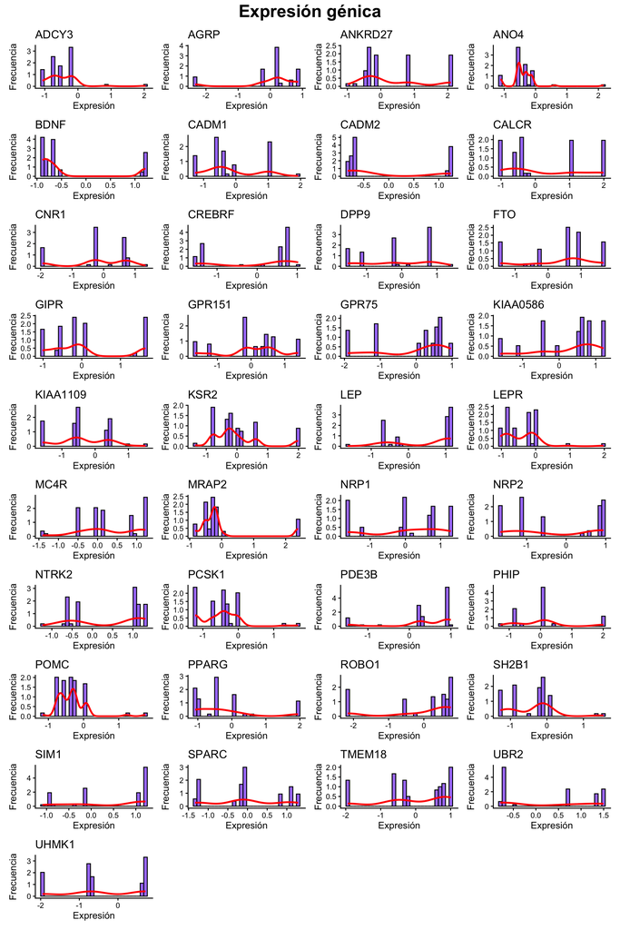

Figura 1. Distribución de la expresión génica.

```r
#-- Graficado de distribucion de la expresion genica para evaluar la normalidad --
list_norm <- list()
for (gen in nombres_genes) {
  df_plot_genes <- data.frame(Expresion = df_genes[[gen]])
  list_norm[[gen]] <- ggplot(df_plot_genes, aes(x = Expresion)) +
  geom_histogram(aes(y = ..density..), bins = 30, fill = "mediumpurple1", color = "black") +
  labs(title = gen,
       x = "Expresión",
       y = "Frecuencia") +
  geom_density(alpha = 1, color = "red", linewidth = 1 ) +
  theme_classic()
}

# Unir todos los graficos en uno con patchwork
reduce(list_norm, `+`) + plot_layout(ncol = 4) + plot_annotation(
  title = "Expresión génica",
  theme = theme(plot.title = element_text(hjust = 0.5, size = 20, face = "bold")))
```

# 3. Análisis de componentes principales (PCA)

El análisis de componentes principales (PCA) es una técnica de aprendizaje no supervisado que permite la reducción de dimensionalidad de los datos para explicar la mayor variabilidad posible (información) mediante combinaciones lineales de los datos en solo unas pocas variables. La selección de componentes principales se realiza de manera que el primer componente principal es el que mayor varianza recoge, el segundo recoge la máxima variabilidad posible que no haya recogido el primer componente, y así sucesivamente, hasta que se recoja el porcentaje de varianza total que se desee. El objetivo es identificar las combinaciones lineales que mejor representen las variables del dataset original.

La **Tabla 2** recoge los umbrales de condición física considerados a partir del índice de masa corporal (IMC), según la organización mundial de la salud (OMS). A la hora de hacer el PCA, los pacientes se agruparán en función de este umbral para tener una mejor comprensión del dataset.

```r
data <- data %>%
  mutate(
    # Crear una categoria de 3 niveles de peso
    cat_imc = case_when(
      imc_kg_m2 < 25 ~ "Normal",
      imc_kg_m2 >= 25 & imc_kg_m2 < 30 ~ "Sobrepeso",
      imc_kg_m2 >= 30 ~ "Obesidad"
    ),

    # Crear una variable BINARIA (para la regresion logistica)
    obesidad = ifelse(imc_kg_m2 >= 30, 1, 0),

    # Convertirla a factor para que la regresion funcione bien
    obesidad = factor(obesidad, labels = c("No", "Si"))
  ) %>%
  relocate(cat_imc, obesidad, .after = imc_kg_m2)

tabla_imc <- data.frame(
  IMC = c( "< 25", "25 ≤ x < 30", "> 30"),
  Condición = c("Normal", "Sobrepeso", "Obesidad")

)
knitr::kable(tabla_imc, align = 'c', caption = "Tabla 2. Umbrales de condición
             física a partir del índice de masa corporal (IMC)",)
```

Tabla 2. Umbrales de condición física a partir del índice de masa corporal (IMC)

| IMC | Condición |
| --- | --- |
| < 25 | Normal |
| 25 ≤ x < 30 | Sobrepeso |
| > 30 | Obesidad |

La **Figura 2** representa el gráfico de sedimentación de la varianza de cada uno de los primeros 15 componentes del PCA. Este gráfico se centra en identificar el número óptimo de componentes principales a retener, buscando el punto de inflexión o “codo” donde la varianza explicada por cada componente adicional disminuye drásticamente, indicando que aportan poca información nueva. Se grafica la varianza (autovalores) frente al número de componente, y se eligen aquellos antes del codo para reducir la dimensionalidad manteniendo la información esencial. Sin embargo, en el caso de este proyecto, no se observa un codo significativo que indique un cambio de tendencia claro, a partir del PC3 se nota una disminución de varianza explicada clara respecto de los PC1 y PC2 pero los siguientes PC siguen disminuyendo esta variable progresivamente. Esto implica que la información y varianza de los datos génicos está repartida entre varios de los genes y no toda solo en unos pocos. Por tanto, el criterio del “codo” no es determinante en este caso, lo que implica la decisión de mantener un mayor número de componentes (6) para asegurar que se captura suficiente variabilidad.

La **Figura 3** representa un biplot de los primeros PC del análisis, agrupados por color según la condición física regida por el umbral de ICM resumido en la Tabla 2.

En este gráfico, se observa un patrón de agrupamiento denso en la zona de los valores negativos del PC1, aquí, se solapan sobretodo los individuos con normopeso (verde) y sobrepeso (amarillo), lo que sugiere que sus perfiles de expresión génica global no presentan diferencias evidentes en estas dos primeras dimensiones.

Destaca la presencia de outliers correspondientes al grupo de Obesidad (rojo) situados en el extremo positivo del PC1 (valores > 8). Estos individuos presentan un perfil transcriptómico muy diferente respecto al resto de la población e incluso de los individos con obesidad que están embebidos en el patrón de agrupamiento mencionado.

Este comportamiento refuerza la decisión anterior de mantener un número alto de componentes (hasta el PC6), ya que la distinción entre las categorías de IMC no se puede graficar solamente a través de dos dimensiones.

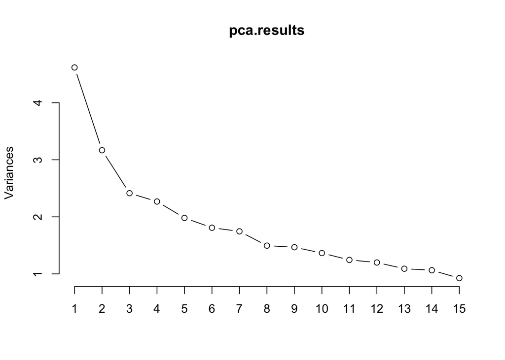

Figura 2. Gráfico de sedimentación de la varianza explicada. Se representa la varianza de cada uno de los primeros 15 componentes principales del análisis.

```r
library(stats)

pca.results <- prcomp(df_genes, center=TRUE, scale.=TRUE)

# Resultado de las componentes principales, x es el elemento de las puntuaciones del
# PCA que devuelve prcomp(). Es lo que estamos buscando.
pca.df <- data.frame(pca.results$x)

# Varianza (cuadrado de la desviacion tipica)
varianzas <- pca.results$sdev^2

# Total de la varianza de los datos
total.varianza <- sum(varianzas)

# Varianza explicada por cada componente principal
varianza.explicada <- varianzas/total.varianza

# Calculamos la varianza acumulada
varianza.acumulada <- cumsum(varianza.explicada)

#Metemos los scores de los primeros 6 PC al dataframe original
data <- cbind(data, pca.df[, 1:6])


# --- Graficado PC1 vs PC2 ---

# Grafico de sedimentacion varianza expl vs PC
screeplot(pca.results, npcs = 15, type= "lines")
```

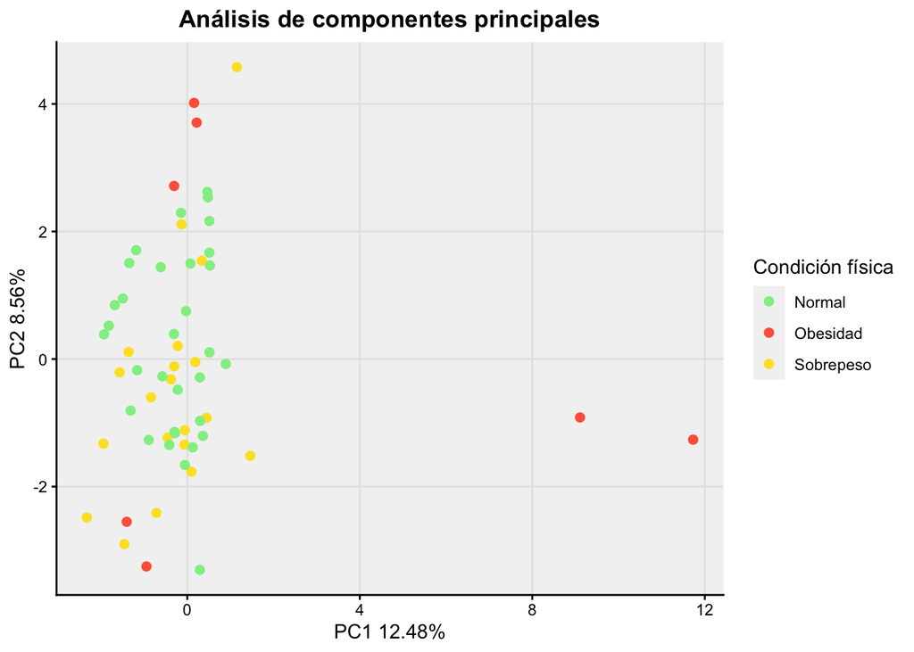

Figura 3. Biplot del PC1 y PC2 del análisis de expresión génica agrupado por condición física.

```r
# Representación grafica de las primeras dos componentes principales (PC1 y PC2)
# en funcion de la categoria imc

# Etiquetas de los ejes del gráfico
x_label <- paste0(paste('PC1', round(varianza.explicada[1] * 100, 2)), '%')
y_label <- paste0(paste('PC2', round(varianza.explicada[2] * 100, 2)), '%')

pca.df$cat_imc <- data$cat_imc

ggplot(pca.df, aes(x=PC1, y=PC2, color=cat_imc)) +
  geom_point(size=2) +
  scale_color_manual(values=c('lightgreen', 'tomato', '#fee12b')) +
  labs(title='Análisis de componentes principales', x=x_label, y=y_label, color='Condición física') +
  theme_classic() +
  theme(panel.grid.major = element_line(color="gray90"), panel.grid.minor = element_blank(),
        panel.background = element_rect(fill = "gray95"), plot.title = element_text(hjust = 0.5, face = "bold"))
```

La **Tabla 3** recoge las proporciones de varianza explicadas de cada uno de los primeros 6 PC así como las varianzas acumuladas. Como hemos comprobado antes con el gráfico de sedimentación representado en la Figura 2, se observa que la varianza no se concentra mayoritariamente en el PC1 sino que se reparte de manera muy gradual a lo largo de los siguientes, acumulando solo hasta un 43.95% de la varianza durante los primeros PC6.

Por su parte, la **Tabla 4** presenta las cargas (*loadings*), que indican la contribución relativa de cada gen a la construcción del componente durante el PCA. La magitud del valor absoluto de la carga indica la contribución del gen a ese PC, mientras que el signo representa la correlación del PC con el valor de expresión del gen.

La manera de entender los PC en este caso es la tendencia global que se descubre haciendo la combinación lineal (lo que hace el PCA) de los 37 genes que actúan coordinados.

```r
# ------- Tabla de Varianza ---------
tabla_varianza <- data.frame(
  Componente = paste0("PC", 1:6),
  R2 = round(varianza.explicada[1:6], 4),
  R2_Acumulado = round(varianza.acumulada[1:6], 4),
  "R2_Acumulado*100%" = paste0((round(varianza.acumulada[1:6], 4)*100), "%")
)

knitr::kable(tabla_varianza,
             col.names = c("Componente", "R2 (Varianza Explicada)", "R2 Acumulado", "R2 Acumulado (%)"),
             caption = "Tabla 3. Componentes PCA y R2. Proporción de varianza explicada de los
             primeros 6 componentes principales.",
             align = 'c')
```

Tabla 3. Componentes PCA y R2. Proporción de varianza explicada de los primeros 6 componentes principales.

| Componente | R2 (Varianza Explicada) | R2 Acumulado | R2 Acumulado (%) |
| --- | --- | --- | --- |
| PC1 | 0.1248 | 0.1248 | 12.48% |
| PC2 | 0.0856 | 0.2104 | 21.04% |
| PC3 | 0.0653 | 0.2757 | 27.57% |
| PC4 | 0.0613 | 0.3370 | 33.7% |
| PC5 | 0.0536 | 0.3906 | 39.06% |
| PC6 | 0.0489 | 0.4395 | 43.95% |

```r
# --------- Tabla de cargas ---------
# Las cargas (rotation) de los primeros 6 componentes
cargas_df <- as.data.frame(pca.results$rotation[, 1:6])

knitr::kable(cargas_df,
             digits = 3,
             caption = "Tabla 4. Cargas del PCA.  Contribución de cada gen a los primeros 6 componentes principales.")
```

Tabla 4. Cargas del PCA. Contribución de cada gen a los primeros 6 componentes principales.

|  | PC1 | PC2 | PC3 | PC4 | PC5 | PC6 |
| --- | --- | --- | --- | --- | --- | --- |
| ADCY3 | 0.331 | -0.086 | 0.095 | -0.095 | 0.058 | -0.067 |
| AGRP | 0.066 | 0.090 | 0.103 | 0.214 | -0.221 | -0.216 |
| ANKRD27 | -0.149 | -0.172 | 0.012 | -0.304 | 0.060 | 0.064 |
| ANO4 | 0.364 | -0.030 | 0.026 | 0.040 | -0.103 | -0.128 |
| BDNF | 0.004 | 0.184 | -0.094 | 0.092 | 0.292 | -0.236 |
| CADM1 | -0.085 | -0.083 | -0.061 | 0.219 | -0.224 | 0.293 |
| CADM2 | -0.009 | 0.326 | 0.052 | 0.177 | 0.155 | 0.232 |
| CALCR | -0.004 | 0.051 | 0.079 | 0.220 | -0.180 | 0.181 |
| CNR1 | 0.090 | -0.041 | -0.118 | -0.191 | -0.148 | -0.011 |
| CREBRF | 0.005 | -0.104 | 0.329 | 0.068 | 0.149 | 0.114 |
| DPP9 | 0.142 | -0.052 | 0.089 | 0.285 | 0.367 | -0.076 |
| FTO | -0.086 | -0.249 | 0.303 | -0.047 | 0.202 | -0.103 |
| GIPR | 0.083 | 0.068 | 0.134 | 0.077 | 0.363 | 0.384 |
| GPR151 | -0.132 | -0.210 | -0.060 | -0.180 | -0.084 | -0.017 |
| GPR75 | -0.117 | 0.074 | -0.098 | -0.039 | 0.019 | -0.336 |
| KIAA0586 | 0.054 | -0.247 | -0.261 | 0.161 | -0.089 | 0.171 |
| KIAA1109 | 0.171 | -0.139 | 0.168 | -0.111 | -0.172 | 0.191 |
| KSR2 | -0.066 | 0.260 | 0.191 | -0.134 | -0.191 | 0.186 |
| LEP | -0.147 | 0.228 | 0.094 | -0.131 | 0.223 | 0.006 |
| LEPR | 0.335 | 0.058 | -0.072 | -0.164 | 0.014 | -0.095 |
| MC4R | -0.225 | -0.147 | 0.088 | 0.299 | 0.012 | -0.182 |
| MRAP2 | 0.017 | -0.016 | -0.422 | 0.028 | 0.118 | -0.045 |
| NRP1 | 0.000 | -0.278 | -0.138 | 0.078 | 0.073 | 0.176 |
| NRP2 | -0.087 | -0.050 | 0.116 | 0.140 | -0.208 | -0.272 |
| NTRK2 | -0.145 | 0.335 | -0.027 | -0.107 | -0.002 | -0.031 |
| PCSK1 | 0.292 | -0.136 | -0.019 | -0.063 | -0.039 | 0.072 |
| PDE3B | -0.153 | -0.042 | 0.192 | 0.126 | -0.268 | 0.109 |
| PHIP | -0.060 | -0.250 | 0.253 | -0.168 | 0.109 | -0.009 |
| POMC | 0.373 | -0.039 | 0.065 | -0.014 | 0.028 | -0.003 |
| PPARG | -0.078 | -0.108 | -0.164 | -0.271 | 0.089 | 0.043 |
| ROBO1 | -0.054 | 0.166 | 0.130 | -0.418 | -0.067 | 0.124 |
| SH2B1 | 0.269 | -0.011 | 0.232 | -0.047 | -0.060 | -0.182 |
| SIM1 | -0.151 | -0.186 | 0.139 | -0.058 | 0.250 | -0.116 |
| SPARC | 0.066 | -0.019 | -0.244 | -0.029 | 0.137 | 0.204 |
| TMEM18 | 0.130 | 0.200 | 0.187 | 0.087 | 0.013 | 0.121 |
| UBR2 | -0.119 | -0.101 | 0.149 | -0.071 | -0.097 | -0.054 |
| UHMK1 | 0.094 | 0.215 | -0.018 | -0.085 | -0.058 | -0.142 |

#### Interpretación del PCA

El análisis de la varianza explicada (ver Tabla 3) revela una estructura de correlación compleja en los datos de expresión génica. El PC1 explica un 12.48% de la varianza total, seguido por un descenso gradual en los siguientez (PC2: 8.56%, PC3: 6.53%), sin que se observe una dominancia clara de la varianza por los primeros.

Al aplicar el criterio de Kaiser (PC con $SD> 1$), observamos que incluso el décimocuarto componente supera este umbral ($SD_{PC14} = 1.032$). Esto indica que la información biológica relevante se encuentra distribuida a lo largo de múltiples dimensiones y no concentrada únicamente en las primeras dos o tres.

Por ello, la selección de los primeros 6 PC es una decisión que permite capturar hasta un 43.95% de varianza acumulada para los análisis posteriores.

# 4. Visualización de datos del PCA

```r
library(FactoMineR)
pca_facto <- PCA(df_genes, ncp=6, graph = FALSE)
```

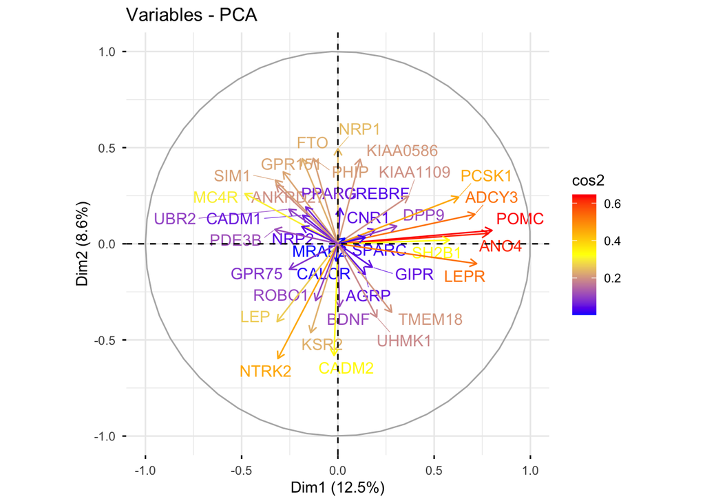

```r
library(factoextra)
fviz_pca_var(pca_facto,
             col.var = "cos2",
             gradient.cols = c("blue", "yellow", "red"),
             repel = TRUE)
```

Al observar el gráfico se puede observar que ha habido una separación de cada gen en el espacio de dos dimensiones. Teniendo en cuenta el cos2, que indica qué tan bien está representado un punto (muestra/individuo) o una variable en el plano o eje factorial que se está observando, los genes mejor representados (y que por lo tanto más relevancia tienen en las primeras dos dimensiones), son *POMC*, *ANO4*, *LEPR*, *ADCY3*, *PCDK1*, *NTRK*. Estos genes se pueden ver clusterizados en su mayoria en la parte derecha del gráfico.

```r
pca_facto_coord <- pca_facto$var$coord
```

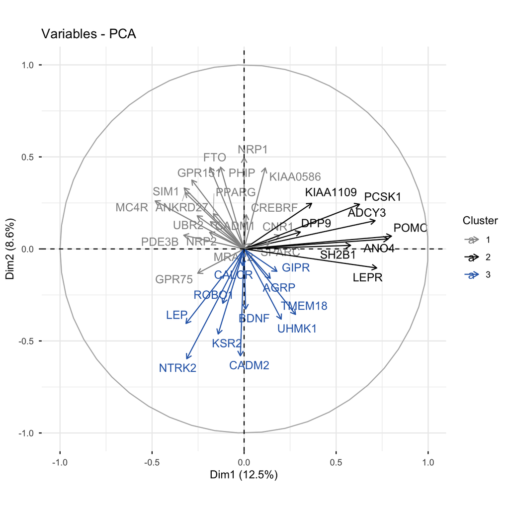

```r
set.seed(42)
km_var <- kmeans(pca_facto_coord, centers = 3)
fviz_pca_var(pca_facto,
             col.var = as.factor(km_var$cluster),
             palette = c("#919191", "black","#2D68B5"), #cada color es un cluster
             legend.title = "Cluster",
             repel = TRUE,
             max.overlaps = Inf
             )
```

Este gráfico es muy similar al anterior, pero en este se pueden observar tres distintos clústers, que agrupa genes según su relación.

Ahora se van a realizar tres gráficos. En estos, se puede observar la contribución de las variables a dimensión 1 (PC1), dimensión 2 (PC2) y la contribución combinada a las dos primeras dimensiones.

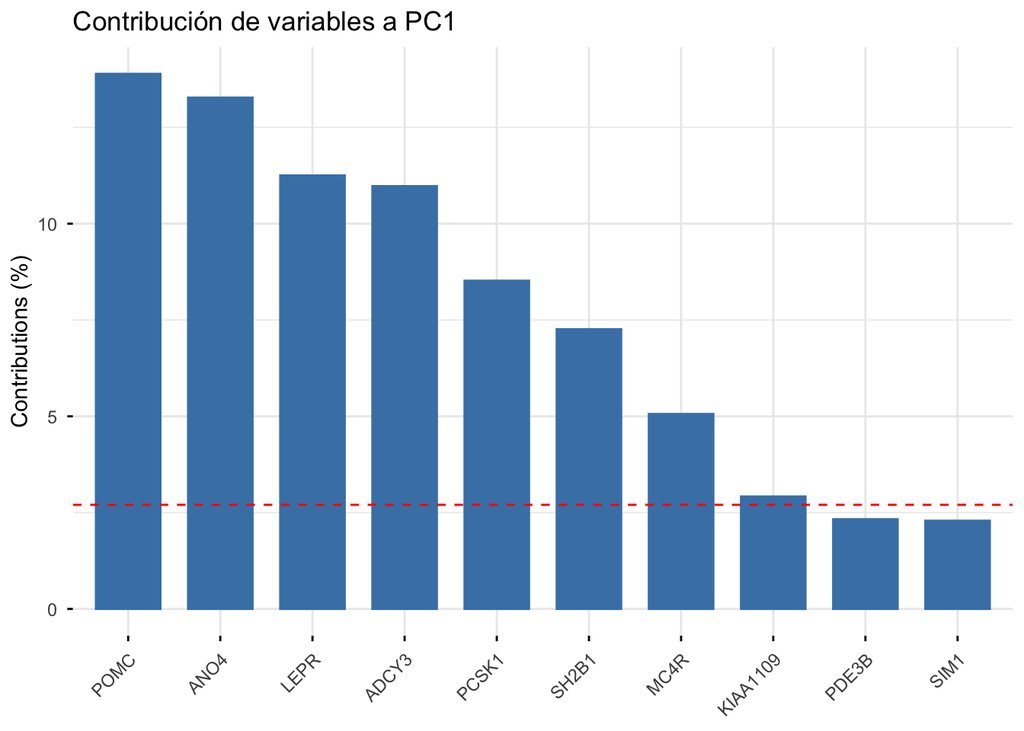

```r
# Contribucion a la dim1 (PC1)
fviz_contrib(pca_facto,
             choice = "var",
             axes = 1,
             top = 10,
             title = "Contribución de variables a PC1")
```

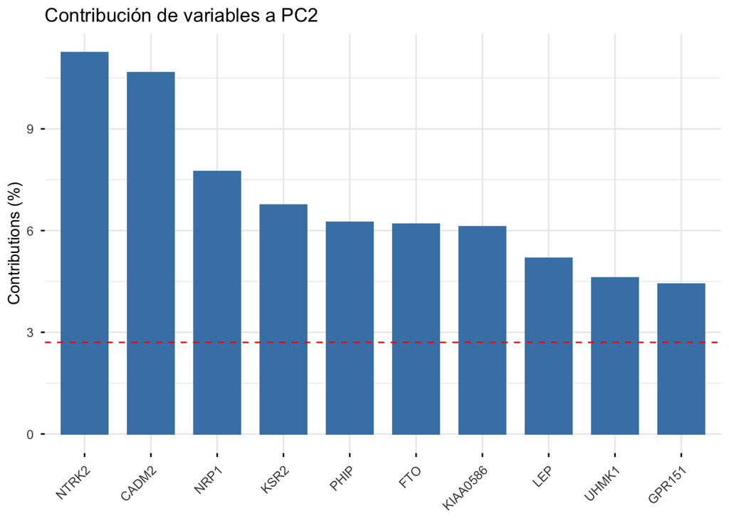

```r
# Contribucion a la dim2 (PC2)
fviz_contrib(pca_facto,
             choice = "var",
             axes = 2,
             top = 10,
             title = "Contribución de variables a PC2")
```

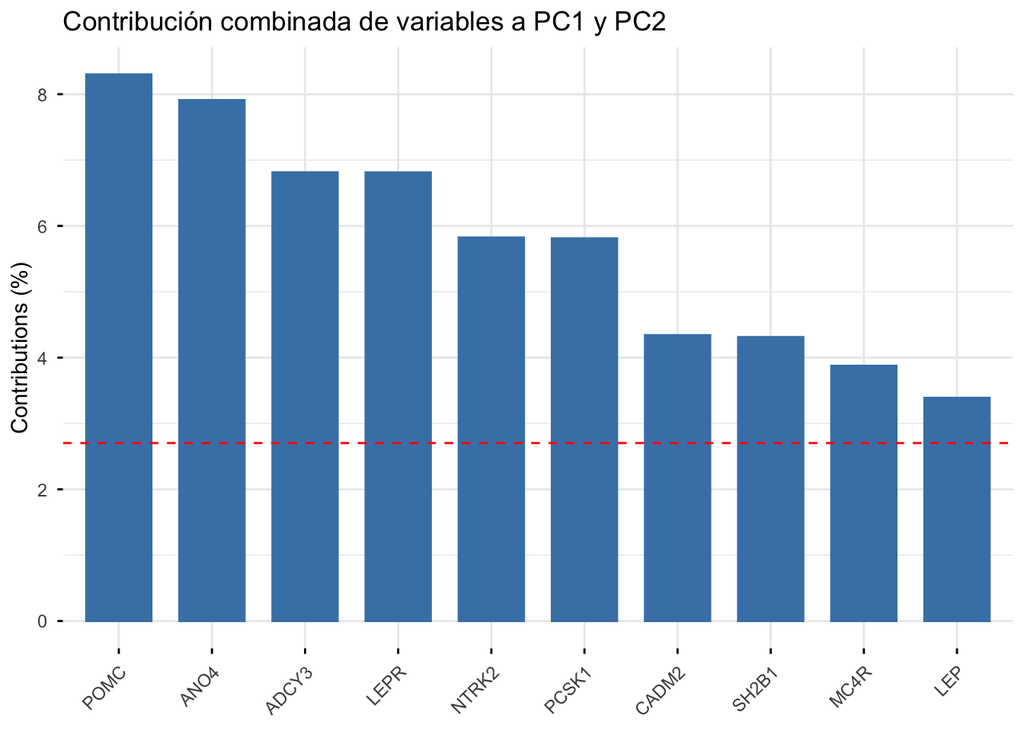

```r
# Contribucion a las dos primeras dimensiones combinadas
fviz_contrib(pca_facto,
             choice = "var",
             axes = 1:2,
             top = 10,
             title = "Contribución combinada de variables a PC1 y PC2")
```

Al observar el gráfico con las contribuciones combinadas, se aprecia que la mayor parte de las contribuciones han sido por parte de los genes *POMC*, *ANO4*, *ADCY3*, *LEPR*, *NTRK2*, *PCSK1*, *CADM*, *SH2B1*, *MC4R* y *LEP*.

Ahora, graficaremos los individuos (pacientes) en el espacio de las primeras dos componentes coloreados por categoría de IMC (Normal, Sobrepeso, Obesidad), a partir de la variable imc_kg_m2.

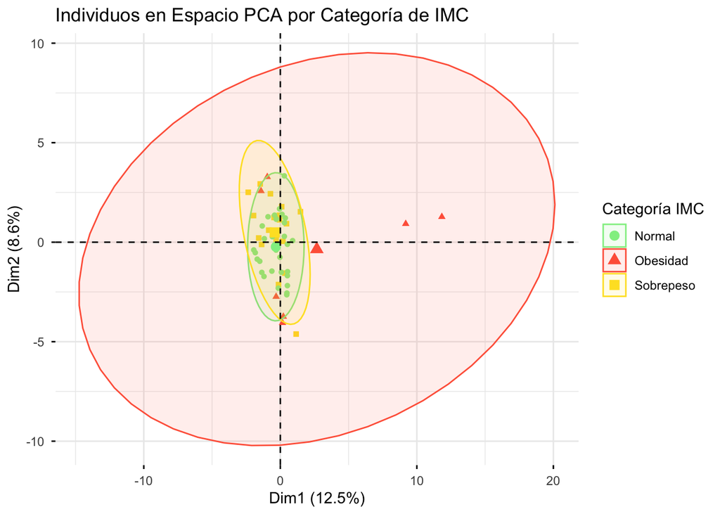

```r
# Gráfica de individuos coloreados por categoría de IMC
fviz_pca_ind(pca_facto,
             geom.ind = "point", # Puntos como formas
             col.ind = data$cat_imc, # Asignar un color a cada grupo
             palette = c("Normal" = "lightgreen",
                         "Sobrepeso" = "#fee12b",
                         "Obesidad" = "tomato"),
             addEllipses = TRUE, # Elipse de confianza
             legend.title = "Categoría IMC",
             title = "Individuos en Espacio PCA por Categoría de IMC",
          )
```

Ahora, realizaremos clustering de individuos (3 clusters) basado en sus scores PCA mediante *k-means*. Después, generaremos un plot para visualizar el resultado:

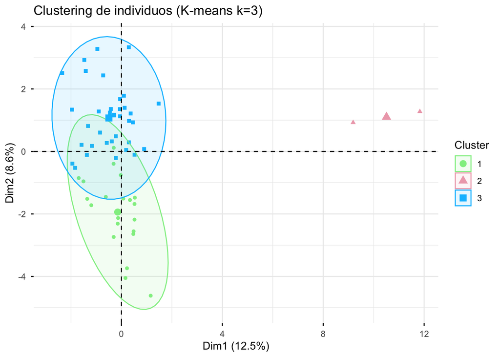

```r
# Extraer scores de individuos en las componentes principales
pca_ind_coord <- pca_facto$ind$coord

# Realizar clustering k-means con 3 clusters
set.seed(456) #reproducibilidad
km_ind <- kmeans(pca_ind_coord,
                 centers = 3,
                 nstart = 25
                 )

# Visualizar clustering de individuos
fviz_pca_ind(pca_facto,
             geom.ind = "point", # puntos
             col.ind = as.factor(km_ind$cluster),
             palette = c("lightgreen", "pink2", "deepskyblue"),
             addEllipses = TRUE,
             legend.title = "Cluster",
             title = "Clustering de individuos (K-means k=3)",
             )
```

# 5. Heatmaps

[figure not shown]

```r
library(corrplot)

# Calculamos la matriz de correlación de Spearman
# Correlacionamos los genes (df_genes) con las primeras 6 PCs (pca_facto$x)
cor_mat <- cor(df_genes,
               pca_facto$x[, 1:6], # 6 PCs del df pca.results
               method = "spearman") # metodo spearman

# Dibujar el heatmap
corrplot(cor_mat,
         method = "color", # usar cuadrados de color
         tl.cex = 0.8,  # tamaño de letra de los genes
         tl.col = "black", # color de las letras
         cl.pos = "r", # posición de la leyenda de colores (derecha)
         cl.cex = 0.7, # Tamaño de letra de la leyenda
         mar = c(1, 1, 3, 1),  # márgenes
         title = "Relación Genes vs. Componentes (Spearman)")
```

# 6. Tabla descriptiva

```r
library(gtsummary)
library(dplyr)

# 1. Crear los terciles para los 3 primeros componentes
data <- data %>%
  mutate(
    PC1_t = cut(PC1,
                breaks = quantile(PC1, probs = seq(0, 1, by = 1/3), na.rm = TRUE),
                labels = c("t1", "t2", "t3"), include.lowest = TRUE),
    PC2_t = cut(PC2,
                breaks = quantile(PC2, probs = seq(0, 1, by = 1/3), na.rm = TRUE),
                labels = c("t1", "t2", "t3"), include.lowest = TRUE),
    PC3_t = cut(PC3,
                breaks = quantile(PC3, probs = seq(0, 1, by = 1/3), na.rm = TRUE),
                labels = c("t1", "t2", "t3"), include.lowest = TRUE)
  )

# 2. Definir qué variables queremos resumir
vars_genes <- colnames(df_genes)
```

Dividimos en terciles para ver si existe una tendencia o relación lineal clara entre los genes y los componentes. Esto se traduce en que si el gen sube porgresivamente del primer tercil al tercer tercil, implica que el gen está vinculado a lo que este componente representa. Además, dividir en terciles resta la influencia de los valores atípicos haciendo que el análisis sea más robusto.

```r
library(gtsummary)
library(dplyr)

# 1. Aseguramos limpieza total de nombres duplicados
data <- data[, !duplicated(colnames(data))]

# 2. Vector de genes (ADCY3 hasta UHMK1)
genes_vector <- colnames(df_genes)

# 3. Forzamos que los genes sean numéricos (por si acaso)
data <- data %>%
  mutate(across(all_of(genes_vector), as.numeric))

# 4. Función optimizada
crear_columna_pca <- function(df, variable_tercil) {
  df %>%
    select(all_of(genes_vector), all_of(variable_tercil)) %>%
    tbl_summary(
      by = all_of(variable_tercil),
      # Forzamos que CUALQUIER variable se trate como continua
      type = all_of(genes_vector) ~ "continuous",
      statistic = all_continuous() ~ "{mean} ({sd})",
      digits = all_continuous() ~ 1,
      missing = "no"
    ) %>%
    add_p(pvalue_fun = ~ style_pvalue(.x, digits = 3))
}

# 5. Generamos las tres partes
tabla1 <- crear_columna_pca(data, "PC1_t")
tabla2 <- crear_columna_pca(data, "PC2_t")
tabla3 <- crear_columna_pca(data, "PC3_t")


tabla_final <- tbl_merge(
  tbls = list(tabla1, tabla2, tabla3),
  tab_spanner = c("**PC1 (Terciles)**", "**PC2 (Terciles)**", "**PC3 (Terciles)**")
) %>%
  modify_header(label = "**Variable Génica**") %>%
  modify_caption("Tabla 5. Tabla descriptiva de expresión génica por terciles de Componentes Principales") %>%
  bold_labels()

tabla_final
```

Tabla 5. Tabla descriptiva de expresión génica por terciles de Componentes Principales

| **Variable Génica** | **PC1 (Terciles)** **t1** N = 20<sup>1</sup> | **PC1 (Terciles)** **t2** N = 19<sup>1</sup> | **PC1 (Terciles)** **t3** N = 20<sup>1</sup> | **PC1 (Terciles)** **p-value**<sup>2</sup> | **PC2 (Terciles)** **t1** N = 20<sup>1</sup> | **PC2 (Terciles)** **t2** N = 19<sup>1</sup> | **PC2 (Terciles)** **t3** N = 20<sup>1</sup> | **PC2 (Terciles)** **p-value**<sup>2</sup> | **PC3 (Terciles)** **t1** N = 20<sup>1</sup> | **PC3 (Terciles)** **t2** N = 19<sup>1</sup> | **PC3 (Terciles)** **t3** N = 20<sup>1</sup> | **PC3 (Terciles)** **p-value**<sup>2</sup> |
| --- | --- | --- | --- | --- | --- | --- | --- | --- | --- | --- | --- | --- |
| ADCY3 | -0.7 (0.3) | -0.5 (0.3) | -0.3 (0.7) | 0.016 | -0.4 (0.4) | -0.5 (0.7) | -0.6 (0.3) | 0.490 | -0.6 (0.3) | -0.3 (0.7) | -0.5 (0.3) | 0.351 |
| AGRP | 0.0 (0.9) | -0.1 (1.0) | 0.2 (0.7) | 0.707 | -0.1 (1.0) | 0.1 (0.7) | 0.1 (0.9) | 0.550 | -0.1 (1.0) | 0.1 (0.9) | 0.1 (0.7) | 0.657 |
| ANKRD27 | 0.6 (0.9) | 0.7 (1.2) | -0.1 (0.7) | 0.046 | 0.6 (1.1) | 0.6 (1.0) | 0.0 (0.8) | 0.040 | 0.5 (1.0) | 0.2 (0.8) | 0.5 (1.1) | 0.719 |
| ANO4 | -0.6 (0.4) | -0.5 (0.3) | -0.2 (0.6) | 0.208 | -0.4 (0.7) | -0.3 (0.3) | -0.5 (0.3) | 0.117 | -0.5 (0.3) | -0.3 (0.7) | -0.5 (0.3) | 0.861 |
| BDNF | -0.6 (0.6) | -0.4 (0.9) | -0.1 (1.0) | 0.208 | -0.5 (0.8) | -0.5 (0.8) | -0.1 (1.0) | 0.154 | -0.3 (0.9) | -0.1 (0.9) | -0.6 (0.6) | 0.587 |
| CADM1 | 0.0 (0.8) | 0.1 (0.9) | -0.5 (0.6) | 0.029 | 0.1 (1.0) | -0.2 (0.8) | -0.3 (0.7) | 0.512 | -0.2 (0.9) | 0.0 (0.8) | -0.3 (0.8) | 0.507 |
| CADM2 | -0.3 (0.8) | -0.1 (0.9) | 0.2 (1.0) | 0.367 | -0.6 (0.4) | -0.2 (0.9) | 0.5 (0.9) | <0.001 | -0.3 (0.8) | -0.1 (0.9) | 0.2 (1.0) | 0.399 |
| CALCR | 0.1 (1.2) | 0.2 (1.1) | 0.4 (1.1) | 0.308 | 0.3 (1.2) | -0.1 (1.0) | 0.4 (1.2) | 0.337 | 0.0 (1.1) | 0.4 (1.2) | 0.3 (1.2) | 0.441 |
| CNR1 | -0.2 (0.9) | -0.3 (1.1) | -0.1 (1.0) | 0.667 | -0.1 (1.0) | -0.2 (0.9) | -0.2 (1.1) | 0.996 | 0.1 (0.8) | -0.2 (0.9) | -0.5 (1.1) | 0.151 |
| CREBRF | -0.3 (1.1) | 0.1 (1.0) | 0.1 (1.0) | 0.322 | 0.3 (0.9) | -0.1 (1.0) | -0.3 (1.1) | 0.316 | -0.6 (1.0) | -0.1 (1.1) | 0.6 (0.5) | 0.001 |
| DPP9 | -0.6 (0.9) | 0.2 (0.7) | 0.0 (1.0) | 0.025 | 0.0 (0.9) | -0.3 (0.9) | -0.2 (1.0) | 0.302 | -0.4 (1.0) | -0.2 (0.9) | 0.1 (0.9) | 0.369 |
| FTO | 0.5 (1.0) | 0.3 (1.0) | 0.3 (1.1) | 0.756 | 0.8 (0.9) | 0.4 (0.7) | -0.2 (1.2) | 0.025 | 0.0 (0.9) | 0.1 (1.1) | 1.0 (0.8) | <0.001 |
| GIPR | -0.3 (0.6) | 0.5 (1.0) | 0.1 (1.0) | 0.042 | 0.1 (1.0) | -0.1 (1.0) | 0.2 (0.8) | 0.402 | -0.1 (0.8) | -0.2 (0.8) | 0.4 (1.1) | 0.128 |
| GPR151 | 0.4 (0.7) | 0.1 (1.0) | -0.4 (0.8) | 0.008 | 0.6 (0.7) | -0.3 (0.8) | -0.2 (0.9) | 0.002 | 0.3 (0.8) | -0.1 (0.9) | 0.0 (0.9) | 0.481 |
| GPR75 | 0.3 (0.7) | -0.1 (1.0) | -0.4 (1.1) | 0.090 | -0.3 (1.1) | 0.0 (0.9) | 0.1 (1.0) | 0.513 | 0.0 (0.9) | 0.0 (1.0) | -0.3 (1.1) | 0.498 |
| KIAA0586 | 0.2 (0.8) | 0.3 (0.8) | 0.2 (1.0) | 0.822 | 0.5 (0.7) | 0.5 (0.5) | -0.3 (1.1) | 0.053 | 0.7 (0.5) | 0.1 (1.0) | 0.0 (0.9) | 0.019 |
| KIAA1109 | -0.4 (0.7) | -0.5 (0.7) | -0.3 (0.9) | 0.830 | -0.1 (0.6) | -0.4 (0.8) | -0.6 (0.8) | 0.028 | -0.6 (0.7) | -0.3 (0.8) | -0.2 (0.7) | 0.250 |
| KSR2 | -0.1 (0.7) | 0.1 (0.8) | 0.0 (1.0) | 0.570 | -0.3 (0.6) | -0.2 (0.4) | 0.5 (1.1) | 0.041 | -0.4 (0.4) | 0.2 (0.9) | 0.2 (0.9) | 0.027 |
| LEP | 0.4 (0.8) | 0.3 (0.9) | 0.6 (0.8) | 0.393 | 0.0 (0.9) | 0.4 (0.8) | 0.9 (0.5) | 0.022 | 0.3 (0.8) | 0.5 (0.9) | 0.6 (0.8) | 0.525 |
| LEPR | -0.6 (0.4) | -0.4 (0.4) | -0.2 (0.7) | 0.057 | -0.5 (0.7) | -0.4 (0.5) | -0.4 (0.4) | 0.399 | -0.4 (0.4) | -0.3 (0.7) | -0.5 (0.4) | 0.778 |
| MC4R | 0.6 (0.6) | 0.5 (0.6) | -0.1 (0.9) | 0.039 | 0.4 (0.8) | 0.3 (0.8) | 0.2 (0.7) | 0.771 | 0.2 (0.7) | 0.3 (0.9) | 0.5 (0.7) | 0.443 |
| MRAP2 | -0.2 (0.7) | 0.0 (1.1) | 0.1 (1.0) | 0.246 | -0.1 (0.9) | 0.1 (1.0) | -0.1 (0.9) | 0.884 | 0.6 (1.4) | -0.3 (0.2) | -0.4 (0.3) | 0.070 |
| NRP1 | 0.2 (1.0) | 0.0 (0.9) | -0.1 (1.2) | 0.674 | 0.4 (0.9) | 0.3 (0.8) | -0.6 (1.1) | 0.009 | 0.3 (0.8) | 0.1 (1.2) | -0.2 (1.1) | 0.454 |
| NRP2 | 0.1 (1.2) | -0.3 (1.2) | -0.5 (0.9) | 0.326 | -0.3 (1.2) | -0.2 (1.0) | -0.2 (1.1) | 0.914 | -0.4 (1.1) | -0.4 (1.1) | 0.1 (1.0) | 0.399 |
| NTRK2 | 0.6 (0.8) | 0.3 (0.9) | 0.4 (0.9) | 0.943 | -0.3 (0.7) | 0.7 (0.8) | 0.9 (0.6) | <0.001 | 0.5 (0.8) | 0.6 (0.8) | 0.2 (0.9) | 0.907 |
| PCSK1 | -0.6 (0.5) | -0.6 (0.5) | -0.4 (0.7) | 0.871 | -0.3 (0.6) | -0.5 (0.7) | -0.7 (0.4) | 0.050 | -0.6 (0.4) | -0.4 (0.8) | -0.6 (0.5) | 0.956 |
| PDE3B | 0.6 (0.4) | 0.4 (0.7) | 0.1 (1.0) | 0.089 | 0.4 (0.8) | 0.4 (0.9) | 0.3 (0.7) | 0.448 | 0.2 (1.0) | 0.5 (0.6) | 0.4 (0.6) | 0.900 |
| PHIP | 0.2 (1.1) | 0.0 (0.8) | -0.1 (0.7) | 0.518 | 0.5 (1.0) | 0.0 (0.8) | -0.3 (0.8) | 0.019 | -0.3 (0.5) | -0.1 (0.9) | 0.6 (1.0) | 0.002 |
| POMC | -0.5 (0.3) | -0.4 (0.2) | -0.1 (0.6) | 0.010 | -0.3 (0.6) | -0.3 (0.5) | -0.4 (0.3) | 0.864 | -0.4 (0.3) | -0.2 (0.7) | -0.3 (0.3) | 0.283 |
| PPARG | 0.1 (1.2) | -0.2 (0.9) | -0.7 (0.5) | 0.064 | -0.1 (1.1) | -0.1 (1.0) | -0.6 (0.5) | 0.258 | 0.0 (1.1) | -0.3 (0.9) | -0.4 (0.7) | 0.510 |
| ROBO1 | 0.1 (0.9) | 0.1 (1.2) | -0.3 (1.2) | 0.158 | -0.2 (1.2) | -0.4 (1.3) | 0.4 (0.4) | 0.401 | -0.2 (1.2) | -0.2 (1.1) | 0.2 (0.9) | 0.527 |
| SH2B1 | -0.6 (0.5) | -0.5 (0.5) | -0.2 (0.7) | 0.317 | -0.4 (0.7) | -0.4 (0.6) | -0.4 (0.5) | 0.917 | -0.8 (0.5) | -0.1 (0.6) | -0.3 (0.4) | <0.001 |
| SIM1 | 0.7 (0.8) | 0.4 (0.9) | 0.3 (0.9) | 0.144 | 0.8 (0.7) | 0.4 (0.9) | 0.3 (0.9) | 0.155 | 0.2 (0.8) | 0.4 (1.0) | 0.8 (0.7) | 0.310 |
| SPARC | -0.1 (0.7) | -0.1 (1.0) | 0.1 (0.9) | 0.687 | 0.0 (0.9) | 0.2 (0.6) | -0.3 (1.0) | 0.195 | 0.2 (0.8) | 0.1 (0.8) | -0.4 (1.0) | 0.050 |
| TMEM18 | -0.5 (1.0) | 0.3 (0.9) | 0.3 (0.9) | 0.030 | -0.3 (1.1) | -0.2 (1.1) | 0.4 (0.6) | 0.179 | -0.4 (0.9) | -0.1 (1.1) | 0.4 (0.8) | 0.014 |
| UBR2 | 0.6 (0.9) | 0.3 (1.0) | -0.1 (0.9) | 0.116 | 0.4 (1.0) | 0.2 (1.0) | 0.1 (1.0) | 0.664 | -0.1 (0.9) | 0.3 (1.1) | 0.4 (1.0) | 0.190 |
| UHMK1 | -0.5 (0.9) | -0.7 (0.9) | 0.1 (1.0) | 0.022 | -0.7 (1.0) | -0.4 (1.0) | 0.0 (0.9) | 0.032 | -0.6 (1.0) | 0.1 (0.8) | -0.6 (1.0) | 0.309 |

<sup>1</sup> Mean (SD)  
<sup>2</sup> Kruskal-Wallis rank sum test

La tabla muestra qué genes son los que tienen más relavancia en cada componente principal. Por ejemplo, el PC2 parece estar fuertemente caracterizado por una regulación positiva de *NTRK2* y *CADM2*, mientras que el PC3 muestra una asociación muy específica con el gen *FTO*, especialmente en el tercil superior.

Para sintetizar esta tabla, vemos que el componente principal 1 (PC1) está fuertemente influenciado por los genes *POMC*, *MC4R*, *TMEM18* y *UHMK1*, genes que tienen un importante papel en la regulación central del balance energético y la saciedad. El componente princial 2 (PC2) está fuertemente influenciado por los genes *CADM2*, *NTRK2* y *UHMK1*, involucrados en la plasticiad neuronal y vías de sañalización transmembrana. Finalmente, el componente principal 3 (PC3) tiene como genes clave *FTO*, *SH2B1*, *TMEM18* y *PHIP* (vemos que se repite *TMEM18* como en el PC1), genes que están relacionados con la obsesidad y la respuesta a la insulina.